# Content

## 3) Let's just give it a try -- what is the difference?

### a) "real" Dy dataset

(code was in a different nb, just copying the results)

Upper pannel: normalize the ensemble mean [but the "band" is composed of the normalization unc. only] Lower pannel: normalize each member; uncertainty afterwards (= OMpy recommendation as on 31Mar)

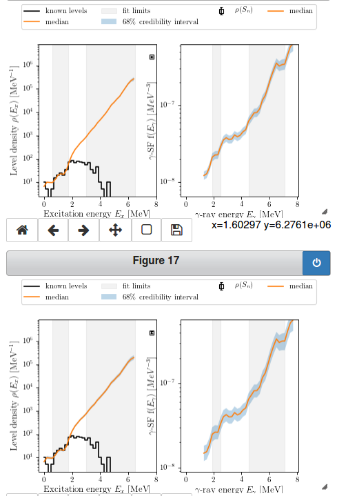

Here we see the lower variance for the *ensemble mean* result.

### b) for the synthetic dataset

-- Here we get problems when normalizing the nld: Due to the very small uncertainty at low energies, the weighted fit is determined almost only from the low energies. In the example, it turns out that this is a problem, as alpha is determined by by the discrete region "only".

If one want to solve this, one would either have to express the likelihood differently, or manually modify the uncertainties

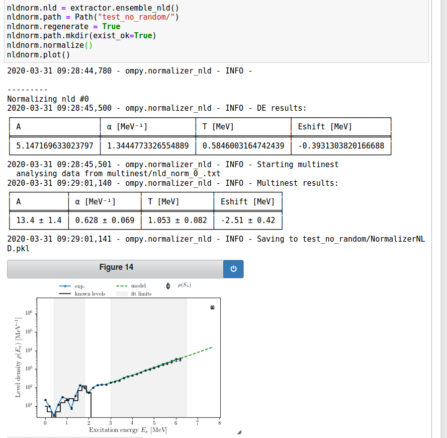

(we have seen though that the normalization works if we do it for each ensemble member as in the article, Fig4 or Fig 5 of the article:

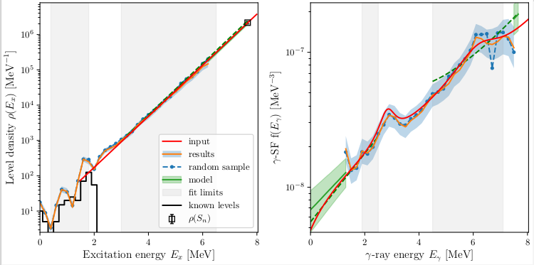

**My summary**: It may be that it sometimes works to normalize the mean nld and gsf. However, it is less general, and may in some cases, like for the second dataset (synthetic Dy dataset) not work. I would thus like to keep the normalization per ensemble member as a feature and general recommendation.

**But of course, OMpy is just a library, and if one want to, one can easily decide to just normalize the ensemble means.**

Just to have the code documented to get the ensemble means:

```
simnorm_mean = copy.deepcopy(simnorm)
simnorm_mean.path = Path("test_no_random/")
simnorm_mean.nld = extractor.ensemble_nld()
simnorm_mean.gsf = extractor.ensemble_gsf()
simnorm_mean.regenerate = True
simnorm_mean.normalize()
```

and combine the statistical and normalization uncertainty:

```
simnorm_mean.plot()
ensemblenorm_sim_mean = copy.deepcopy(ensemblenorm_sim)

# use each member (to get statistical uncertainties), but transform
# with the same normalization parameters, obtained from simnorm_mean
ensemblenorm_sim_mean.extractor.nld = extractor.nld
ensemblenorm_sim_mean.extractor.gsf = extractor.gsf

ensemblenorm_sim_mean.res = [simnorm_mean.res for i in extractor.nld]

ensemblenorm_sim_mean.plot(n_plot=0)
```